# **Face Mask Prediction using U-Net**

### **Define dice coefficient function**

- Create a function to calculate dice coefficient

```python
def dice_coefficient(y_true, y_pred):
    numerator = 2 * tensorflow.reduce_sum(y_true * y_pred)
    denominator = tensorflow.reduce_sum(y_true + y_pred)

    return numerator / (denominator + tensorflow.keras.backend.epsilon())
```

### **Define loss function**

```python
def loss(y_true, y_pred):
    return binary_crossentropy(y_true, y_pred) - tensorflow.keras.backend.log(dice_coefficient(y_true, y_pred) + tensorflow.keras.backend.epsilon())
```

### **Compile the model**

- Complie the model using below parameters
  - loss: use the loss function defined above
  - optimizers: use Adam optimizer
  - metrics: use dice_coefficient function defined above

```python
from tensorflow.keras.optimizers import Adam
from tensorflow.keras.losses import binary_crossentropy

optimizer = Adam(lr=1e-4, beta_1=0.9, beta_2=0.999, epsilon=None, decay=0.0, amsgrad=False)
model.compile(loss=loss, optimizer=optimizer, metrics=[dice_coefficient])
```

### **Define callbacks**

- Use ModelCheckpoint
- Use EarlyStopping
- Use ReduceLROnPlateau

```python
from tensorflow.keras.callbacks import ModelCheckpoint, EarlyStopping, ReduceLROnPlateau

checkpoint = ModelCheckpoint("model-{val_loss:.2f}.h5", monitor="val_loss", verbose=1, save_best_only=True, save_weights_only=True)

stop = EarlyStopping(monitor="val_loss", patience=5)

reduce_lr = ReduceLROnPlateau(monitor="val_loss", factor=0.2, patience=5, min_lr=1e-6, verbose=1)
```

### **Fit the model**

- Fit the model using below parameters
  - epochs: *10*
  - batch_size: 1
  - callbacks: use the callbacks defined above

```python
model.fit(X_train, y_train, validation_data = (X_train, y_train), epochs=10, batch_size=1, verbose=1,  callbacks=[checkpoint,stop,reduce_lr])
```

```
Epoch 00001: val_loss improved from inf to 1.36122, saving model to model-1.36.h5
Epoch 00002: val_loss improved from 1.36122 to 1.09721, saving model to model-1.10.h5
Epoch 00003: val_loss improved from 1.09721 to 0.99244, saving model to model-0.99.h5
Epoch 00004: val_loss improved from 0.99244 to 0.94179, saving model to model-0.94.h5
Epoch 00005: val_loss improved from 0.94179 to 0.91037, saving model to model-0.91.h5
Epoch 00006: val_loss improved from 0.91037 to 0.88625, saving model to model-0.89.h5
Epoch 00007: val_loss improved from 0.88625 to 0.85852, saving model to model-0.86.h5
Epoch 00008: val_loss improved from 0.85852 to 0.84238, saving model to model-0.84.h5
Epoch 00009: val_loss improved from 0.84238 to 0.83050, saving model to model-0.83.h5
Epoch 00010: val_loss improved from 0.83050 to 0.82390, saving model to model-0.82.h5
```

```
<tensorflow.python.keras.callbacks.History at 0x7f2bb72eaf28>
```

### **Get the predicted mask for a test image**

```python
# Predict on train, val and test
preds_train = model.predict(X_train, verbose=1)
preds_test = model.predict(X_test, verbose=1)
```

- Show the test image

```
Clipping input data to the valid range for imshow with RGB data ([0..1] for floats or [0..255] for integers).
```

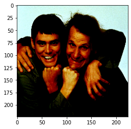

```python
plt.imshow(X_test[0])
```

- Show original mask for test image

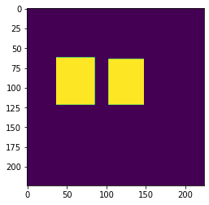

```python
plt.imshow(y_test[0])
```

- Predict the mask on the test image

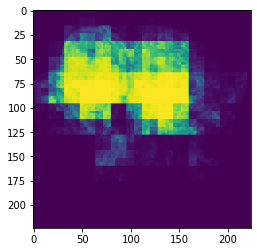

```python
plt.imshow(preds_test[0])
```